# R/Bioconductor tools for mass spectrometry-based proteomics

# 3 Handling raw MS data

The `mzR` package provides an interface to the [proteowizard](http://proteowizard.sourceforge.net/) code base, the legacy RAMP is a non-sequential parser and other C/C++ code to access various raw data files, such as `mzML`, `mzXML`, `netCDF`, and `mzData`. The data is accessed on-disk, i.e it does not get loaded entirely in memory by default. The three main functions are `openMSfile` to create a file handle to a raw data file, `header` to extract metadata about the spectra contained in the file and `peaks` to extract one or multiple spectra of interest. Other functions such as `instrumentInfo`, or `runInfo` can be used to gather general information about a run.

```r
library("mzR")
ms <- openMSfile(mzf)
ms
```

```
## Mass Spectrometry file handle.
## Filename:  TMT_Erwinia_1uLSike_Top10HCD_isol2_45stepped_60min_01-20141210.mzML
## Number of scans:  7534
```

```r
hd <- header(ms)
dim(hd)
```

```
## [1] 7534   21
```

```r
names(hd)
```

```
##  [1] "seqNum"                   "acquisitionNum"
##  [3] "msLevel"                  "polarity"
##  [5] "peaksCount"               "totIonCurrent"
##  [7] "retentionTime"            "basePeakMZ"
##  [9] "basePeakIntensity"        "collisionEnergy"
## [11] "ionisationEnergy"         "lowMZ"
## [13] "highMZ"                   "precursorScanNum"
## [15] "precursorMZ"              "precursorCharge"
## [17] "precursorIntensity"       "mergedScan"
## [19] "mergedResultScanNum"      "mergedResultStartScanNum"
## [21] "mergedResultEndScanNum"
```

```r
head(peaks(ms, 234))
```

```
##          [,1]        [,2]
## [1,] 100.3852    93.86617
## [2,] 101.6572    83.94572
## [3,] 107.3893    91.63007
## [4,] 112.0505 15697.57129
## [5,] 113.0538   106.47455
## [6,] 113.3050    83.92274
```

```r
str(peaks(ms, 1:5))
```

```
## List of 5
##  $ : num [1:25800, 1:2] 400 400 400 400 400 ...
##  $ : num [1:25934, 1:2] 400 400 400 400 400 ...
##  $ : num [1:26148, 1:2] 400 400 400 400 400 ...
##  $ : num [1:26330, 1:2] 400 400 400 400 400 ...
##  $ : num [1:26463, 1:2] 400 400 400 400 400 ...
```

> **Exercise** Extract the index of the MS2 spectrum with the highest base peak intensity and plot its spectrum (we will see more about MS data visualisation in the next section). Is the data centroided or in profile mode?

```r
hd2 <- hd[hd$msLevel == 2, ]
i <- which.max(hd2$basePeakIntensity)
hd2[i, ]
```

```
##      seqNum acquisitionNum msLevel polarity peaksCount totIonCurrent
## 5404   5404           5404       2       -1        275    2283283712
##      retentionTime basePeakMZ basePeakIntensity collisionEnergy
## 5404      2751.313   859.5032         354288224              45
##      ionisationEnergy    lowMZ  highMZ precursorScanNum precursorMZ
## 5404                0 100.5031 1995.63             5403    859.1722
##      precursorCharge precursorIntensity mergedScan mergedResultScanNum
## 5404               3          627820480          0                   0
##      mergedResultStartScanNum mergedResultEndScanNum
## 5404                        0                      0
```

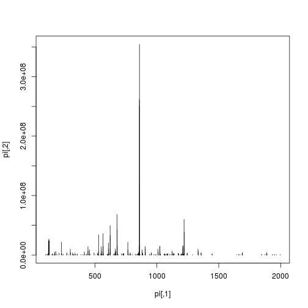

```r
pi <- peaks(ms, hd2[i, 1])
plot(pi, type = "h")
```

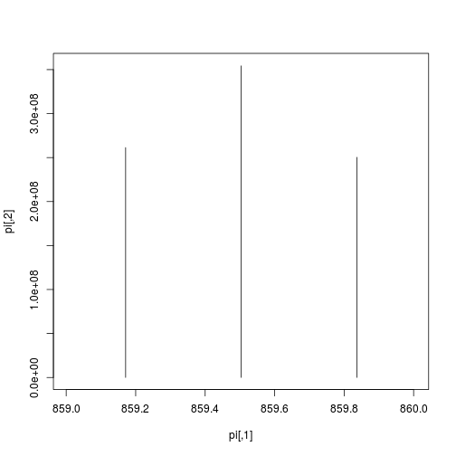

```r
mz <- hd2[i, "basePeakMZ"]
plot(pi, type = "h", xlim = c(mz-0.5, mz+0.5))
```

Zooming into spectrum 100.

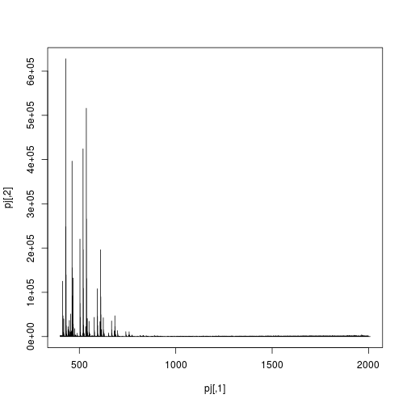

```r
pj <- peaks(ms, 100)
plot(pj, type = "l")
```

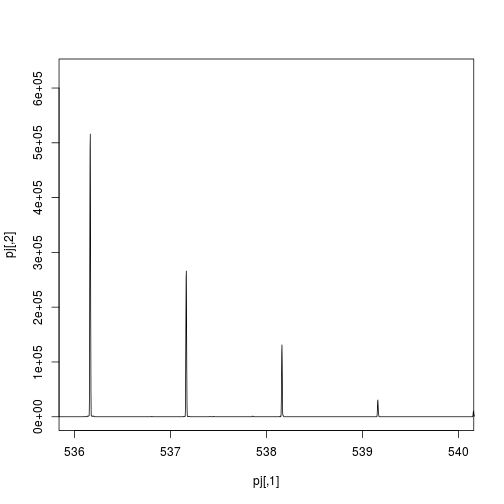

```r
plot(pj, type = "l", xlim = c(536,540))
```

# 4 Handling identification data

The `ProteomicsBioc2016Workshop` package distributes a small identification result file (see `?TMT_Erwinia_1uLSike_Top10HCD_isol2_45stepped_60min_01.mzid`) that we load and parse using infrastructure from the *mzID* package.

```r
library("mzID")
(f <- dir(system.file("extdata", package = "ProteomicsBioc2016Workshop"),
         pattern = "mzid", full.names = TRUE))
```

```
## [1] "/home/lg390/R/x86_64-pc-linux-gnu-library/3.3rel/ProteomicsBioc2016Workshop/extdata/TMT_Erwinia.mzid.gz"
```

```r
id <- mzID(f)
```

```
## reading TMT_Erwinia.mzid.gz... DONE!
```

```r
software(id)
```

```
##         version   name          id
## 1 Beta (v10072) MS-GF+ ID_software
```

```r
id
```

```
## An mzID object
##
## Software used:   MS-GF+ (version: Beta (v10072))
##
## Rawfile:         /home/lgatto/dev/00_github/RforProteomics/sandbox/TMT_Erwinia_1uLSike_Top10HCD_isol2_45stepped_60min_01.mzXML
##
## Database:        /home/lgatto/dev/00_github/RforProteomics/sandbox/erwinia_carotovora.fasta
##
## Number of scans: 5287
## Number of PSM's: 5563
```

Various data can be extracted from the `mzID` object, using one the accessor functions such as `database`, `sofware`, `scans`, `peptides`, … The object can also be converted into a `data.frame` using the `flatten` function.

```r
head(flatten(id))
```

```
##   spectrumid scan number(s) acquisitionnum passthreshold rank
## 1  scan=5782           5782           5782          TRUE    1
## 2  scan=6037           6037           6037          TRUE    1
## 3  scan=5235           5235           5235          TRUE    1
##   calculatedmasstocharge experimentalmasstocharge chargestate
## 1              1080.2321                1080.2325           3
## 2              1002.2115                1002.2089           3
## 3              1189.2800                1189.2836           3
##   ms-gf:denovoscore ms-gf:evalue ms-gf:rawscore ms-gf:specevalue
## 1               174 5.430080e-21            147     3.764831e-27
## 2               245 9.943751e-20            214     6.902626e-26
## 3               264 2.564787e-19            211     1.778789e-25
##   assumeddissociationmethod isotopeerror isdecoy post pre end start
## 1                       HCD            0   FALSE    S   R  84    50
## 2                       HCD            0   FALSE    R   K 315   288
```

[output cut: 22 more lines]

The `mzR` interface provides a similar interface. It is however much faster as it does not read all the data into memory and only extracts relevant data on demand. It has also accessor functions such as `softwareInfo`, `mzidInfo`, … (use `showMethods(classes = "mzRident", where = "package:mzR")`) to see all available methods.

```r
library("mzR")
id2 <- openIDfile(f)
id2
```

```
## Identification file handle.
## Filename:  TMT_Erwinia.mzid.gz
## Number of psms:  5655
```

```r
softwareInfo(id2)
```

```
## [1] "MS-GF+ Beta (v10072) "
## [2] "ProteoWizard MzIdentML 3.0.6239 ProteoWizard"
```

The identification data can be accessed as a `data.frame` with the `psms` accessor.

```r
head(psms(id2))
```

```
##   spectrumID chargeState rank passThreshold experimentalMassToCharge
## 1  scan=5782           3    1          TRUE                1080.2325
## 2  scan=6037           3    1          TRUE                1002.2089
## 3  scan=5235           3    1          TRUE                1189.2836
## 4  scan=5397           3    1          TRUE                 960.5365
## 5  scan=6075           3    1          TRUE                1264.3409
##   calculatedMassToCharge                            sequence modNum
## 1              1080.2321 PVQIQAGEDSNVIGALGGAVLGGFLGNTIGGGSGR      0
## 2              1002.2115        TQVLDGLINANDIEVPVALIDGEIDVLR      0
## 3              1189.2800   TKGLNVMQNLLTAHPDVQAVFAQNDEMALGALR      0
## 4               960.5365         SQILQQAGTSVLSQANQVPQTVLSLLR      0
## 5              1264.3419 PIIGDNPFVVVLPDVVLDESTADQTQENLALLISR      0
##   isDecoy post pre start end DatabaseAccess DBseqLength DatabaseSeq
## 1   FALSE    S   R    50  84        ECA1932         155
## 2   FALSE    R   K   288 315        ECA1147         434
## 3   FALSE    A   R   192 224        ECA0013         295
## 4   FALSE    -   R   264 290        ECA1731         290
## 5   FALSE    F   R   119 153        ECA1443         298
##                                         DatabaseDescription acquisitionNum
## 1                        ECA1932 outer membrane lipoprotein           5782
## 2                                    ECA1147 trigger factor           6037
## 3                ECA0013 ribose-binding periplasmic protein           5235
## 4                                         ECA1731 flagellin           5397
## 5      ECA1443 UTP--glucose-1-phosphate uridylyltransferase           6075
##  [ reached getOption("max.print") -- omitted 1 row ]
```

> **Exercise** Is there a relation between the length of a protein and the number of identified peptides, conditioned by the (average) e-value of the identifications?

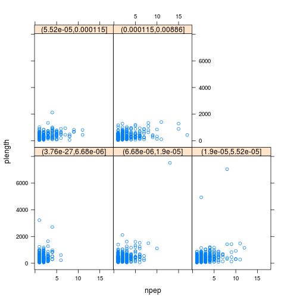

```r
fid <- flatten(id)
x <- by(fid, fid$accession, function(x)
    c(unique(x$length),
      length(unique(x$pepseq)),
      mean(x$'ms-gf:specevalue')))
x <- data.frame(do.call(rbind, x))
colnames(x) <- c("plength", "npep", "eval")
x$bins <- cut(x$eval, summary(x$eval))
library("lattice")
xyplot(plength ~ npep | bins, data = x)
```

# 5 MS/MS database search

While searches are generally performed using third-party software independently of R or can be started from R using a `system` call, the *rTANDEM* package allows one to execute such searches using the X!Tandem engine.

```r
library("rTANDEM")
?rtandem
```

The *MSGPplus* package provides an interface to the very fast `MSGF+` engine.

```r
library("MSGFplus")
parameters <- msgfPar(database = 'milk-proteins.fasta',
                      tolerance = '20 ppm',
                      instrument = 'TOF')
runMSGF(parameters, 'msraw.mzML')
```

# 6 High-level data interface

The above sections introduced low-level interfaces to raw and identification results. The *MSnbase* package provides abstractions for raw data through the `MSnExp` class and containers for quantification data via the `MSnSet` class. Both store the actual assay data (spectra or quantitation matrix) and sample and feature metadata, accessed with `spectra` (or the `[`, `[[` operators) or `exprs`, `pData` and `fData`.

The figure below give a schematics of an `MSnSet` instance and the relation between the assay data and the respective feature and sample metadata.

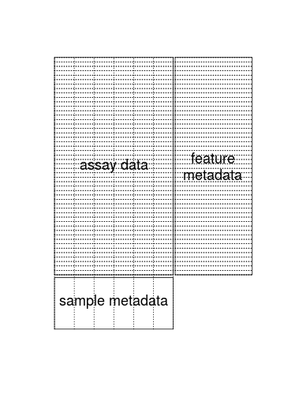

Another useful slot is `processingData`, accessed with `processingData(.)`, that records all the processing that objects have undergone since their creation (see examples below).

The `readMSData` will parse the raw data, extract the MS2 spectra and construct an MS experiment file.

```r
library("MSnbase")
quantFile <- dir(system.file(package = "MSnbase", dir = "extdata"),
                 full.name = TRUE, pattern = "mzXML$")
quantFile
```

```
## [1] "/home/lg390/R/x86_64-pc-linux-gnu-library/3.3rel/MSnbase/extdata/dummyiTRAQ.mzXML"
```

```r
msexp <- readMSData(quantFile, verbose=FALSE)
msexp
```

```
## Object of class "MSnExp"
##  Object size in memory: 0.2 Mb
## - - - Spectra data - - -
##  MS level(s): 2
##  Number of MS1 acquisitions: 1
##  Number of MSn scans: 5
##  Number of precursor ions: 5
##  4 unique MZs
##  Precursor MZ's: 437.8 - 716.34
##  MSn M/Z range: 100 2016.66
##  MSn retention times: 25:1 - 25:2 minutes
## - - - Processing information - - -
## Data loaded: Sun Jun 26 19:14:39 2016
##  MSnbase version: 1.21.7
## - - - Meta data  - - -
## phenoData
##   rowNames: dummyiTRAQ.mzXML
##   varLabels: sampleNames
##   varMetadata: labelDescription
## Loaded from:
##   dummyiTRAQ.mzXML
## protocolData: none
## featureData
##   featureNames: X1.1 X2.1 ... X5.1 (5 total)
##   fvarLabels: spectrum
##   fvarMetadata: labelDescription
## experimentData: use 'experimentData(object)'
```

The identification results stemming from the same raw data file can then be used to add PSM matches.

```r
## find path to a mzIdentML file
identFile <- dir(system.file(package = "MSnbase", dir = "extdata"),
                 full.name = TRUE, pattern = "mzid$")
identFile
```

```
## [1] "/home/lg390/R/x86_64-pc-linux-gnu-library/3.3rel/MSnbase/extdata/dummyiTRAQ.mzid"
```

```r
msexp <- addIdentificationData(msexp, identFile)
```

```
## reading dummyiTRAQ.mzid... DONE!
```

```r
fData(msexp)
```

```
##      spectrum scan number(s) passthreshold rank calculatedmasstocharge
## X1.1        1              1          TRUE    1               645.0375
## X2.1        2              2          TRUE    1               546.9633
## X3.1        3             NA            NA   NA                     NA
##      experimentalmasstocharge chargestate ms-gf:denovoscore ms-gf:evalue
## X1.1                 645.3741           3                77     79.36958
## X2.1                 546.9586           3                39     13.46615
## X3.1                       NA          NA                NA           NA
##      ms-gf:rawscore ms-gf:specevalue assumeddissociationmethod
## X1.1            -39     5.527468e-05                       CID
## X2.1            -30     9.399048e-06                       CID
## X3.1             NA               NA                      <NA>
##      isotopeerror isdecoy post  pre end start       accession length
## X1.1            1   FALSE    A    R 186   170 ECA0984;ECA3829    231
## X2.1            0   FALSE    A    K  62    50         ECA1028    275
## X3.1         <NA>      NA <NA> <NA>  NA    NA            <NA>     NA
##                                                                      description
## X1.1 DNA mismatch repair protein;acetolactate synthase isozyme III large subunit
## X2.1          2,3,4,5-tetrahydropyridine-2,6-dicarboxylate N-succinyltransferase
## X3.1                                                                        <NA>
##                 pepseq modified modification          idFile
## X1.1 VESITARHGEVLQLRPK    FALSE           NA dummyiTRAQ.mzid
## X2.1     IDGQWVTHQWLKK    FALSE           NA dummyiTRAQ.mzid
## X3.1              <NA>       NA           NA            <NA>
##                  databaseFile nprot npep.prot npsm.prot npsm.pep
## X1.1 erwinia_carotovora.fasta     2         1         1        1
## X2.1 erwinia_carotovora.fasta     1         1         1        1
## X3.1                     <NA>    NA        NA        NA       NA
##  [ reached getOption("max.print") -- omitted 2 rows ]
```

```r
msexp[[1]]
```

```
## Object of class "Spectrum2"
##  Precursor: 645.3741
##  Retention time: 25:1
##  Charge: 3
##  MSn level: 2
##  Peaks count: 2921
##  Total ion count: 668170086
```

```r
as(msexp[[1]], "data.frame")[100:105, ]
```

```
##           mz          i
## 100 141.0990 588594.812
## 101 141.1015 845401.250
## 102 141.1041 791352.125
## 103 141.1066 477623.000
## 104 141.1091 155376.312
## 105 141.1117   4752.541
```

`MSnExp` object load all MS data into memory. This is a viable solution for MS2 data, but does not scale to MS1 data, especially when multiple files are loaded together. With the help of [Johannes Rainer](http://github.com/jotsetung), a new `MSnExp` class supporting on disk access is being developed.

# 7 Visualising raw data

## 7.1 A full chromatogram

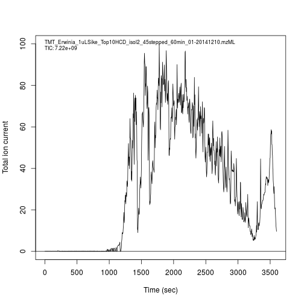

```r
chromatogram(ms)
```

## 7.2 Multiple chromatograms

It is of course possible to overlay several chromatograms. The code chunks below are not executed dynamically so save time with downloading raw data files.

```r
## manual download
library("RforProteomics")
url <- "http://proteome.sysbiol.cam.ac.uk/lgatto/files/Thermo-HELA-PRT/"
f1 <- downloadData(file.path(url, "Thermo_Hela_PRTC_1.mzML"))
f2 <- downloadData(file.path(url, "Thermo_Hela_PRTC_2.mzML"))
f3 <- downloadData(file.path(url, "Thermo_Hela_PRTC_3.mzML"))
```

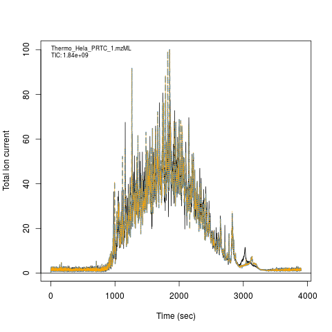

```r
## plotting
c1 <- chromatogram(f1)
c2 <- chromatogram(f2, plot = FALSE)
lines(c2, col = "steelblue", lty = "dashed", lwd = 2)
c3 <- chromatogram(f3, plot = FALSE)
lines(c2, col = "orange", lty = "dotted")
```

## 7.3 An extracted ion chromatogram

```r
par(mfrow = c(1, 2))
xic(ms, mz = 636.925, width = 0.01)
x <- xic(ms, mz = 636.925, width = 0.01, rtlim = c(2120, 2200))
```

[figure not shown]

## 7.4 Spectra

We first load a test iTRAQ data called `itraqdata` and distributed as part of the *MSnbase* package using the `data` function. This is a pre-packaged data that comes as a dedicated data structure called `MSnExp`. We then `plot` the 10th spectrum using specific code that recognises what to do with an element of an `MSnExp`.

```r
data(itraqdata)
itraqdata
```

```
## Object of class "MSnExp"
##  Object size in memory: 1.88 Mb
## - - - Spectra data - - -
##  MS level(s): 2
##  Number of MS1 acquisitions: 1
##  Number of MSn scans: 55
##  Number of precursor ions: 55
##  55 unique MZs
##  Precursor MZ's: 401.74 - 1236.1
##  MSn M/Z range: 100 2069.27
##  MSn retention times: 19:9 - 50:18 minutes
## - - - Processing information - - -
## Data loaded: Wed May 11 18:54:39 2011
##  MSnbase version: 1.1.22
## - - - Meta data  - - -
## phenoData
##   rowNames: 1
##   varLabels: sampleNames sampleNumbers
##   varMetadata: labelDescription
## Loaded from:
##   dummyiTRAQ.mzXML
## protocolData: none
## featureData
##   featureNames: X1 X10 ... X9 (55 total)
##   fvarLabels: spectrum ProteinAccession ProteinDescription
##     PeptideSequence
##   fvarMetadata: labelDescription
## experimentData: use 'experimentData(object)'
```

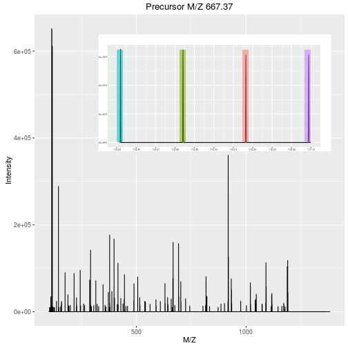

```r
plot(itraqdata[[10]], reporters = iTRAQ4, full=TRUE)
```

The `ms` data is not pre-packaged as an `MSnExp` data. It is a more bare-bone mzRramp object, a pointer to a raw data file (here TMT_Erwinia_1uLSike_Top10HCD_isol2_45stepped_60min_01-20141210.mzML): we need first to extract a spectrum of interest (here the 3071st spectrum, an MS1 spectrum), and use the generic `plot` function to visualise the spectrum.

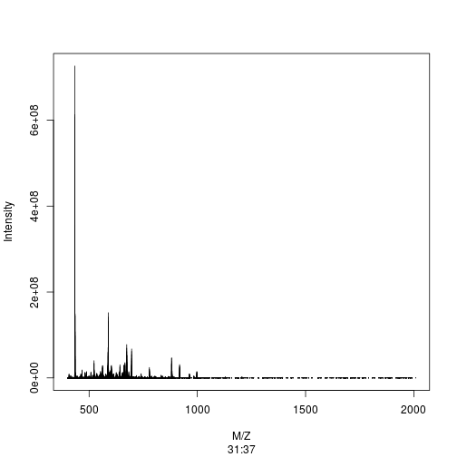

```r
plot(peaks(ms, 3071), type = "h",
     xlab = "M/Z", ylab = "Intensity",
     sub = formatRt(hd[3071, "retentionTime"]))
```

The importance of flexible access to specialised data becomes visible in the figure below (taken from the *RforProteomics* [visualisation vignette](http://bioconductor.org/packages/release/data/experiment/vignettes/RforProteomics/inst/doc/RProtVis.html)). **Not only can we access specific data and understand/visualise them, but we can transverse all the data and extracted/visualise/understand structured slices of data.**

In this code chunks we start by selecting relevant spectra of interest. We will focus on the first MS1 spectrum acquired after 30 minutes of retention time.

```r
## (1) Open raw data file
ms <- openMSfile(mzf)
## (2) Extract the header information
hd <- header(ms)
## (3) MS1 spectra indices
ms1 <- which(hd$msLevel == 1)
## (4) Select MS1 spectra with retention time between 30 and 35 minutes
rtsel <- hd$retentionTime[ms1] / 60 > 30 & hd$retentionTime[ms1] / 60 < 35
## (5) Indices of the 1st and 2nd MS1 spectra after 30 minutes
i <- ms1[which(rtsel)][1]
j <- ms1[which(rtsel)][2]
## (6) Interleaved MS2 spectra
ms2 <- (i+1):(j-1)
```

Now now extract and plot all relevant information:

1. The upper panel represents the chromatogram of the TMT_Erwinia_1uLSike_Top10HCD_isol2_45stepped_60min_01-20141210.mzML raw data file, produced with `chromatogram`.

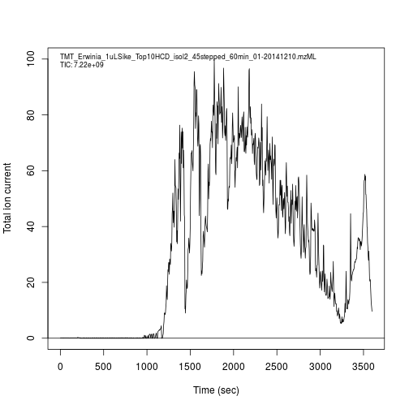

```r
chromatogram(ms)
```

2. We concentrate at a specific retention time, 30:1 minutes (1800.6836 seconds)

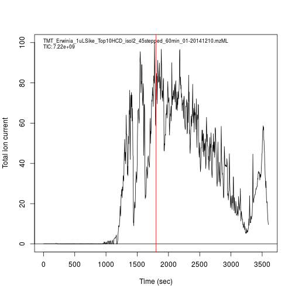

```r
chromatogram(ms)
abline(v = hd[i, "retentionTime"], col = "red")
```

3. This corresponds to the 2807th MS1 spectrum, shown on the second row of figures.

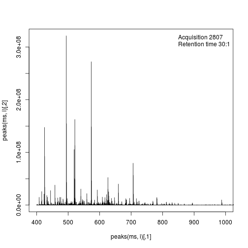

```r
plot(peaks(ms, i), type = "l", xlim = c(400, 1000))
legend("topright", bty = "n",
       legend = paste0(
           "Acquisition ", hd[i, "acquisitionNum"],  "\n",
           "Retention time ", formatRt(hd[i, "retentionTime"])))
```

4. The ions that were selected for MS2 are highlighted by vertical lines. These are represented in the bottom part of the figure.

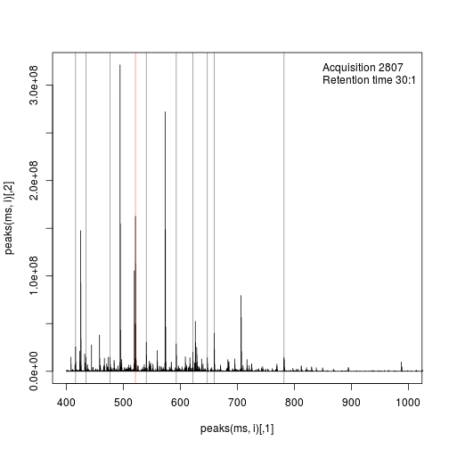

```r
plot(peaks(ms, i), type = "l", xlim = c(400, 1000))
legend("topright", bty = "n",
       legend = paste0(
           "Acquisition ", hd[i, "acquisitionNum"],  "\n",
           "Retention time ", formatRt(hd[i, "retentionTime"])))
abline(v = hd[ms2, "precursorMZ"],
       col = c("#FF000080",
           rep("#12121280", 9)))
```

5. On the right, we zoom on the isotopic envelope of one peptide in particular (the one highlighted with a red line).

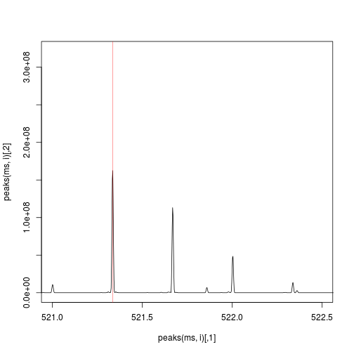

```r
plot(peaks(ms, i), type = "l", xlim = c(521, 522.5))
abline(v = hd[ms2, "precursorMZ"], col = "#FF000080")
```

6. A final loop through the relevant MS2 spectra plots the `length(ms2)` MS2 spectra highlighted above.

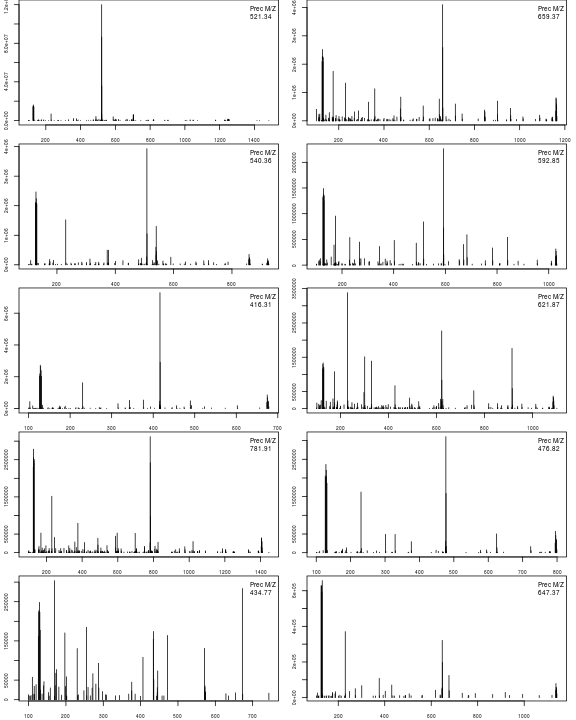

```r
par(mfrow = c(5, 2), mar = c(2, 2, 0, 1))
for (ii in ms2) {
    p <- peaks(ms, ii)
    plot(p, xlab = "", ylab = "", type = "h", cex.axis = .6)
    legend("topright", legend = paste0("Prec M/Z\n",
                           round(hd[ii, "precursorMZ"], 2)),
           bty = "n", cex = .8)
}
```

Putting it all together:

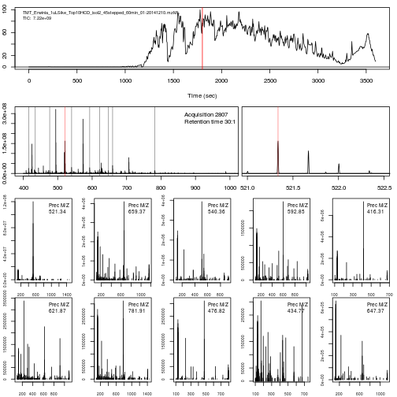

```r
layout(lout)
par(mar=c(4,2,1,1))
chromatogram(ms)

abline(v = hd[i, "retentionTime"], col = "red")
par(mar = c(3, 2, 1, 0))
plot(peaks(ms, i), type = "l", xlim = c(400, 1000))
legend("topright", bty = "n",
       legend = paste0(
           "Acquisition ", hd[i, "acquisitionNum"],  "\n",
           "Retention time ", formatRt(hd[i, "retentionTime"])))
abline(h = 0)
abline(v = hd[ms2, "precursorMZ"],
       col = c("#FF000080",
           rep("#12121280", 9)))

par(mar = c(3, 0.5, 1, 1))
plot(peaks(ms, i), type = "l", xlim = c(521, 522.5),
     yaxt = "n")
abline(h = 0)
abline(v = hd[ms2, "precursorMZ"], col = "#FF000080")

par(mar = c(2, 2, 0, 1))
for (ii in ms2) {
    p <- peaks(ms, ii)
    plot(p, xlab = "", ylab = "", type = "h", cex.axis = .6)
    legend("topright", legend = paste0("Prec M/Z\n",
                           round(hd[ii, "precursorMZ"], 2)),
           bty = "n", cex = .8)
}
```

Below, we illustrate some additional visualisation and animations of raw MS data, also taken from the *RforProteomics* [visualisation vignette](http://bioconductor.org/packages/release/data/experiment/vignettes/RforProteomics/inst/doc/RProtVis.html). On the left, we have a heatmap visualisation of a MS map and a 3 dimensional representation of the same data. On the right, 2 MS1 spectra in blue and the set of interleaves 10 MS2 spectra.

```r
## (1) MS space heaptmap
M <- MSmap(ms, ms1[rtsel], 521, 523, .005, hd)
```

```
## 1
```

```r
ff <- colorRampPalette(c("yellow", "steelblue"))
trellis.par.set(regions=list(col=ff(100)))
m1 <- plot(M, aspect = 1, allTicks = FALSE)
## (2) Same data as (1), in 3 dimenstion
M@map[msMap(M) == 0] <- NA
m2 <- plot3D(M, rgl = FALSE)
## (3) The 2 MS1 and 10 interleaved MS2 spectra from above
i <- ms1[which(rtsel)][1]
j <- ms1[which(rtsel)][2]
M2 <- MSmap(ms, i:j, 100, 1000, 1, hd)
```

```
## 1
```

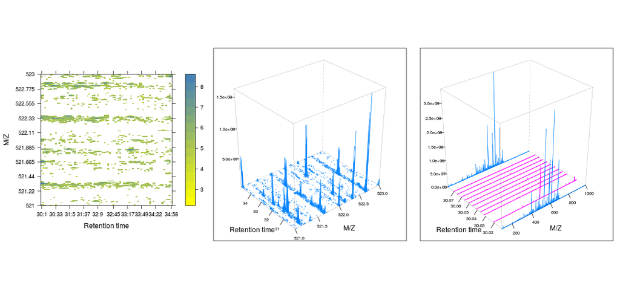

```r
m3 <- plot3D(M2)
grid.arrange(m1, m2, m3, ncol = 3)
```

# 8 Visualising identification data

Annotated spectra and comparing spectra.

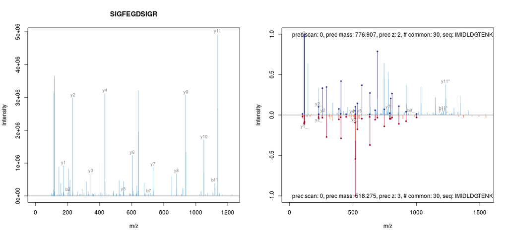

```r
par(mfrow = c(1, 2))
itraqdata2 <- pickPeaks(itraqdata, verbose = FALSE)
s <- "SIGFEGDSIGR"
plot(itraqdata2[[14]], s, main = s)
plot(itraqdata2[[25]], itraqdata2[[28]], sequences = rep("IMIDLDGTENK", 2))
```

The annotation of spectra is obtained by simulating fragmentation of a peptide and matching observed peaks to fragments:

```r
calculateFragments("SIGFEGDSIGR")
```

```
## Modifications used: C=57.02146
```

```
##            mz  ion type pos z         seq
## 1    88.03931   b1    b   1 1           S
## 2   201.12337   b2    b   2 1          SI
## 3   258.14483   b3    b   3 1         SIG
## 4   405.21324   b4    b   4 1        SIGF
## 5   534.25583   b5    b   5 1       SIGFE
## 6   591.27729   b6    b   6 1      SIGFEG
## 7   706.30423   b7    b   7 1     SIGFEGD
## 8   793.33626   b8    b   8 1    SIGFEGDS
## 9   906.42032   b9    b   9 1   SIGFEGDSI
## 10  963.44178  b10    b  10 1  SIGFEGDSIG
## 11 1119.54289  b11    b  11 1 SIGFEGDSIGR
## 12  175.11895   y1    y   1 1           R
## 13  232.14041   y2    y   2 1          GR
## 14  345.22447   y3    y   3 1         IGR
## 15  432.25650   y4    y   4 1        SIGR
## 16  547.28344   y5    y   5 1       DSIGR
##  [ reached getOption("max.print") -- omitted 20 rows ]
```

There are 2 Bioconductor packages for peptide-spectrum matching directly in R, namely *MSGFplus* and *rTANDEM*, replying on `MSGF+` and `X!TANDEM` respectively. See also the *MSGFgui* package for visualisation of identification data.

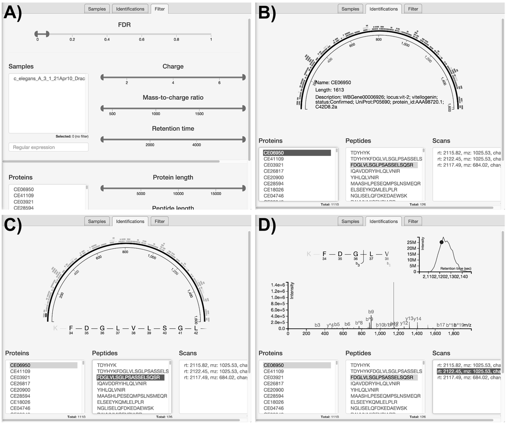

# 9 Quantitative proteomics data

There are a wide range of proteomics quantitation techniques that can broadly be classified as labelled vs. label-free, depending whether the features are labelled prior the MS acquisition and the MS level at which quantitation is inferred, namely MS1 or MS2.

|  | Label-free | Labelled |
| --- | --- | --- |
| MS1 | XIC | SILAC, 15N |
| MS2 | Counting | iTRAQ, TMT |

- Isobaric tagging (iTRAQ and TMT): *MSnbase* and *isobar*.
- Label-free: *xcms* (metabolomics).
- Counting: *MSnbase* and *MSnID* for peptide-spectrum matching confidence assessment.
- *N14N15* for heavy Nitrogen-labelled data.

## 9.1 From raw data to quantitative data

In terms of raw data quantitation, most efforts have been devoted to MS2-level quantitation. Label-free XIC quantitation has however been addressed in the frame of metabolomics data processing by the [`xcms`](http://bioconductor.org/packages/release/bioc/html/xcms.html) infrastructure.

### 9.1.1 Isobaric tagging

An `MSnExp` is converted to an `MSnSet` by the `quantitation` method. Below, we use the iTRAQ 4-plex isobaric tagging strategy (defined by the `iTRAQ4` parameter; other isobaric tags are available).

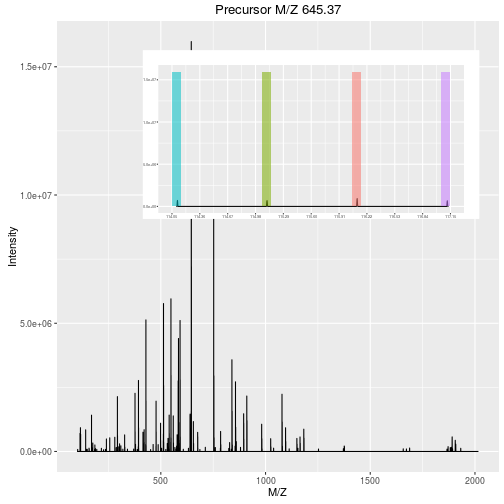

```r
plot(msexp[[1]], full=TRUE, reporters = iTRAQ4)
```

```r
msset <- quantify(msexp, method = "trap", reporters = iTRAQ4, verbose = FALSE)
exprs(msset)
```

```
##      iTRAQ4.114 iTRAQ4.115 iTRAQ4.116 iTRAQ4.117
## X1.1   4483.320   4873.996   6743.441   4601.378
## X2.1   1918.082   1418.040   1117.601   1581.954
## X3.1  15210.979  15296.256  15592.760  16550.502
## X4.1   4133.103   5069.983   4724.845   4694.801
## X5.1  11947.881  13061.875  12809.491  12911.479
```

```r
processingData(msset)
```

```
## - - - Processing information - - -
## Data loaded: Sun Jun 26 19:14:39 2016
## iTRAQ4 quantification by trapezoidation: Sun Jun 26 19:15:07 2016
##  MSnbase version: 1.21.7
```

**See also** The *isobar* package supports quantitation from centroided `mgf` peak lists or its own tab-separated files that can be generated from Mascot and Phenyx vendor files.

### 9.1.2 Label-free MS2

Other MS2 quantitation methods available in `quantify` include the (normalised) spectral index `SI` and (normalised) spectral abundance factor `SAF` or simply a simple count method.

```r
exprs(si <- quantify(msexp, method = "SIn"))
```

```
## Combined 2 features into 2 using sum
```

```
##         dummyiTRAQ.mzXML
## ECA0510      0.003588641
## ECA1028      0.001470129
```

```r
exprs(saf <- quantify(msexp, method = "NSAF"))
```

```
## Combined 2 features into 2 using user-defined function
```

```
##         dummyiTRAQ.mzXML
## ECA0510        0.6235828
## ECA1028        0.3764172
```

Note that spectra that have not been assigned any peptide (`NA`) or that match non-unique peptides (`npsm > 1`) are discarded in the counting process.

### 9.1.3 Spectral counting

The *MSnID* package provides enables to explore and assess the confidence of identification data using `mzid` files. A subset of all peptide-spectrum matches, that pass a specific false discovery rate threshold can them be converted to an `MSnSet`, where the number of peptide occurrences are used to populate the assay data.

## 9.2 Importing third-party data

The PSI `mzTab` file format is aimed at providing a simpler (than XML formats) and more accessible file format to the wider community. It is composed of a key-value metadata section and peptide/protein/small molecule tabular sections.

```r
mztf <- pxget(px, pxfiles(px)[2])
```

```
## F063721.dat-mztab.txt already present.
```

```r
(mzt <- readMzTabData(mztf, what = "PEP", version = "0.9"))
```

```
## Detected a metadata section
```

```
## Detected a peptide section
```

```
## MSnSet (storageMode: lockedEnvironment)
## assayData: 1528 features, 6 samples
##   element names: exprs
## protocolData: none
## phenoData
##   rowNames: sub[1] sub[2] ... sub[6] (6 total)
##   varLabels: abundance
##   varMetadata: labelDescription
## featureData
##   featureNames: 1 2 ... 1528 (1528 total)
##   fvarLabels: sequence accession ... uri (14 total)
##   fvarMetadata: labelDescription
## experimentData: use 'experimentData(object)'
## Annotation:
## - - - Processing information - - -
## mzTab read: Sun Jun 26 19:15:14 2016
##  MSnbase version: 1.21.7
```

It is also possible to import arbitrary spreadsheets as `MSnSet` objects into R with the `readMSnSet2` function. The main 2 arguments of the function are (1) a text-based spreadsheet or a `data.frame` and (2) column names of indices that identify the quantitation data.

```r
csv <- dir(system.file ("extdata" , package = "pRolocdata"),
           full.names = TRUE, pattern = "pr800866n_si_004-rep1.csv")
getEcols(csv, split = ",")
```

```
##  [1] "\"Protein ID\""              "\"FBgn\""
##  [3] "\"Flybase Symbol\""          "\"No. peptide IDs\""
##  [5] "\"Mascot score\""            "\"No. peptides quantified\""
##  [7] "\"area 114\""                "\"area 115\""
##  [9] "\"area 116\""                "\"area 117\""
## [11] "\"PLS-DA classification\""   "\"Peptide sequence\""
## [13] "\"Precursor ion mass\""      "\"Precursor ion charge\""
## [15] "\"pd.2013\""                 "\"pd.markers\""
```

```r
ecols <- 7:10
res <- readMSnSet2(csv, ecols)
head(exprs(res))
```

```
##   area.114 area.115 area.116 area.117
## 1 0.379000 0.281000 0.225000 0.114000
## 2 0.420000 0.209667 0.206111 0.163889
## 3 0.187333 0.167333 0.169667 0.476000
## 4 0.247500 0.253000 0.320000 0.179000
## 5 0.216000 0.183000 0.342000 0.259000
## 6 0.072000 0.212333 0.573000 0.142667
```

```r
head(fData(res))
```

```
##   Protein.ID        FBgn Flybase.Symbol No..peptide.IDs Mascot.score
## 1    CG10060 FBgn0001104    G-ialpha65A               3       179.86
## 2    CG10067 FBgn0000044         Act57B               5       222.40
## 3    CG10077 FBgn0035720        CG10077               5       219.65
## 4    CG10079 FBgn0003731           Egfr               2        86.39
## 5    CG10106 FBgn0029506        Tsp42Ee               1        52.10
## 6    CG10130 FBgn0010638      Sec61beta               2        79.90
##   No..peptides.quantified PLS.DA.classification Peptide.sequence
## 1                       1                    PM
## 2                       9                    PM
## 3                       3
## 4                       2                    PM
## 5                       1                              GGVFDTIQK
## 6                       3              ER/Golgi
##   Precursor.ion.mass Precursor.ion.charge     pd.2013 pd.markers
## 1                                                  PM    unknown
## 2                                                  PM    unknown
## 3                                             unknown    unknown
## 4                                                  PM    unknown
## 5            626.887                    2 Phenotype 1    unknown
## 6                                            ER/Golgi         ER
```

# 10 Quantitative data processing and analysis

## 10.1 Processing

Processing quantitative proteomics data is very similar to processing transcriptomics data. When working with `MSnSet` instances, a set of methods for data processing and visualisation are readily available to streamline and track the process:

- `purityCorrect` to correct for isobaric tag impurities
- `normalise` (or `normalize`) to, well, normalise data using quantile, vsn, mean, … normalisation
- `filterNA` to remove feature with (a certain proportion) of missing values
- `impute` to impute missing values using a wide range of methods (more on this below)
- `image`, `MAplot`, `plot2D` (for dimensionality reduction using PCA, t-SNE, MDS, …), … to visualise data
- …

## 10.2 Differentially expression

- Isobaric tagging (iTRAQ and TMT): *isobar*
- Label-free: *[aLFQ](http://cran.fhcrc.org/web/packages/aLFQ/index.html)* and *[protiq](http://cran.fhcrc.org/web/packages/protiq/index.html)*
- *msmsTests* for the RNA-seq count-based models and tests

```r
library("msmsTests")
data(msms.dataset) ## an MSnSet
e <- pp.msms.data(msms.dataset)
head(exprs(e))
```

```
##         U2.2502.1 U2.2502.2 U2.2502.3 U2.2502.4 U6.2502.1 U6.2502.2
## YJR104C       156       176       201       203       194       208
## YKL060C       183       205       202       171       171       171
## YDR155C       180       184       198       185       161       160
## YGR192C       176       172       174       170       170       171
## YOL086C       171       182       137       103       159       164
## YLR150W        97       111       104       100        99       103
##         U6.2502.3 U6.2502.4 U2.0302.1 U2.0302.2 U2.0302.3 U6.0302.1
## YJR104C       215       217       246       266       261       249
## YKL060C       149       144       247       249       236       278
## YDR155C       166       168       193       175       155       179
## YGR192C       162       167       243       310       270       270
## YOL086C       116       113       409       384       364       395
## YLR150W        98       103        73        90        96        79
##         U6.0302.2 U6.0302.3
## YJR104C       240       265
## YKL060C       252       247
## YDR155C       165       154
## YGR192C       275       259
## YOL086C       358       355
## YLR150W        81        88
```

```r
pData(e)
```

```
##           treat batch
## U2.2502.1  U200  2502
## U2.2502.2  U200  2502
## U2.2502.3  U200  2502
## U2.2502.4  U200  2502
## U6.2502.1  U600  2502
## U6.2502.2  U600  2502
## U6.2502.3  U600  2502
## U6.2502.4  U600  2502
## U2.0302.1  U200  0302
## U2.0302.2  U200  0302
## U2.0302.3  U200  0302
## U6.0302.1  U600  0302
## U6.0302.2  U600  0302
## U6.0302.3  U600  0302
```

```r
null.f <- "y~batch"
alt.f <- "y~treat+batch"
div <- apply(exprs(e),2,sum)
res <- msms.edgeR(e,alt.f,null.f,div=div,fnm="treat")
head(res)
```

```
##               LogFC         LR     p.value
## YJR104C  0.02689909  0.2691922 0.603874157
## YKL060C -0.12646368  5.5829487 0.018136162
## YDR155C -0.18781161 10.2706901 0.001351602
## YGR192C -0.08495735  2.5941286 0.107260419
## YOL086C -0.11853786  5.7558869 0.016433498
## YLR150W -0.09299164  1.3766331 0.240675481
```

- *MSstats* for various statistical analyses
- and of course *limma*
- …

## 10.3 Machine learning

- `MSnSet` support *MLInterfaces* out-of-the-box.
- While tailor for spatial proteomics data, *pRoloc*’s machine learning methods are useful in a wide range of cases and work with `MSnSet` instances.

# 11 Some differences with RNASeq and transcriptomics in general

## 11.1 Missing values

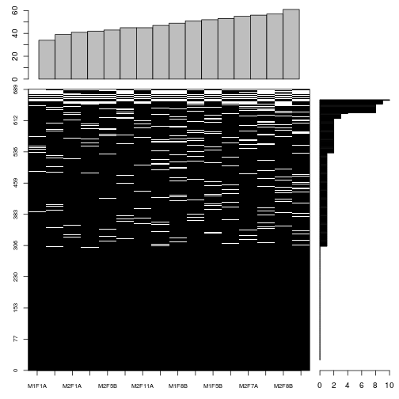

```
## features.na
##   0   1   2   3   4   8   9  10
## 301 247  91  13   2  23  10   2
## samples.na
## 34 39 41 42 43 45 47 49 51 52 53 55 56 57 61
##  1  1  1  1  1  2  1  1  1  1  1  1  1  1  1
```

```r
data(naset)
naplot(naset, col = "black")
```

### 11.1.1 Filtering

One solution is to remove all or part of the features that have missing values (see `?filterNA`).

```r
flt <- filterNA(naset)
processingData(flt)
```

```
## - - - Processing information - - -
## Subset [689,16][301,16] Sun Jun 26 19:15:15 2016
## Removed features with more than 0 NAs: Sun Jun 26 19:15:15 2016
## Dropped featureData's levels Sun Jun 26 19:15:15 2016
##  MSnbase version: 1.15.6
```

### 11.1.2 Identification transfer

Identification transfer between acquisitions (label-free): if a feature was not acquired in MS2 in one replicate, it is possible to find the ion in MS space based on the M/Z and retention time coordinates of the same ion in a replicate where it was identified. (An example of this is implemented in the *synapter* package).

### 11.1.3 Imputation

It is of course possible to impute missing values (`?impute`). This is however not a straightforward thing, as is likely to dramatically fail when a high proportion of data is missing (10s of %). But also, there are two types of mechanisms resulting in missing values in LC/MSMS experiments.

- Missing values resulting from absence of detection of a feature, despite ions being present at detectable concentrations. For example in the case of ion suppression or as a result from the stochastic, data-dependent nature of the MS acquisition method. These missing value are expected to be randomly distributed in the data and are defined as **missing at random** (MAR) or **missing completely at random** (MCAR).
- Biologically relevant missing values, resulting from the *absence* or the low abundance of ions (below the limit of detection of the instrument). These missing values are not expected to be randomly distributed in the data and are defined as **missing not at random** (MNAR).

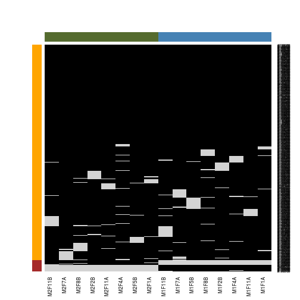

Different imputation methods are more appropriate to different classes of missing values (as documented in this [paper](http://pubs.acs.org/doi/abs/10.1021/acs.jproteome.5b00981)). Values missing at random, and those missing not at random should be imputed with different methods.

## 11.2 Coverage

- Coverage in proteomics in `%`
- [Coverage](http://www.ncbi.nlm.nih.gov/pubmed/24434847) in RNA-Seq in fold `X`

The following values are higher bounds, *without* peptide filtering for about 80000 *gene groups*

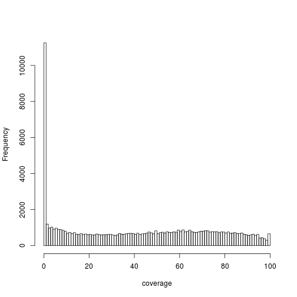

```r
data(cvg)
hist(cvg$coverage, breaks = 100, xlab = "coverage", main = "")
```

And

- the majority of peptides map to a minority of proteins different
- peptides within one protein can be differently detectable in MS acquisitions